# RESULTS DOC

Outputs for the ASCENT-03 historical ECA.

## Study Details

| Study element | Description |
| --- | --- |
| Study title | Characteristics and Outcomes of Patients with Metastatic Triple-Negative Breast Cancer (mTNBC) Treated with First-line TPC Chemotherapy as a historical External Control Arm for ASCENT-03 Trial: A Retr… |
| Protocol ID | GS-US-593-7865 |
| Study period | December 18th 2010 - June 30th 2025 |
| Patient identification period | January 1st 2011 - April 22nd 2020 |
| RW cohort data cut-off date | June 30th 2025 |
| ASCENT-03 data cut-off date | April 2nd 2025 [Primary Analysis] |
| DARS ID | 2025-ONC-077 |
| DARS filepath | //solasdata/cds_obs_heor/data_analytics/2025/2025-ONC-077/ |
| GitHub respository | [https://github.com/Gilead-CDS-RWE/2025-ONC-077–A03-ECA/](https://github.com/Gilead-CDS-RWE/2025-ONC-077--A03-ECA/) |
| Redshift data schema name | flatiron_cc_breast_ascent_eca_raw_20251011 |

## Attrition table - RW cohort

| **No.** | **Eligibility criteria** | **N remaining** | **N excluded** | **% remaining of previous step** |
| --- | --- | --- | --- | --- |
| 0 | Total patients in Flatiron Health Custom Data Solution for ASCENT-03 External Control Arm - Primary Cohort | 491 | NA | NA |
| 1 | mBC diagnosis on after January 1, 2011 | 491 | 0 | 100.0% |
| 2 | Aged 18+ at mBC diagnosis | 491 | 0 | 100.0% |
| 3 | Evidence of HER2 negative, ER negative, and PR negative and the absence of positive test for HER2 or ER or PR within +/- 60 days of mBC diagnosis | 489 | −2 | 99.6% |
| 4 | First line of mTNBC treatment confirmed as either paclitaxel, nab-paclitaxel, or carboplatin and gemcitabine, and initiated on or before December 31, 2023 | 472 | −17 | 96.5% |
| 5 | No other primary malignancy within 5 years before mBC diagnosis | 450 | −22 | 95.3% |
| 6 | No participation in a clinical trial during the index treatment | 450 | 0 | 100.0% |
| 7 | Initiated first line of mTNBC treatment before SG approval date in mTNBC (April 22, 2020) | 288 | −162 | 64.0% |
| 8 | Exclude if ECOG >=2 on the closest record to index date in the period 90 days pre-index date up to and including 7 days post index date | 245 | −43 | 85.1% |
| 9 | Exclude if evidence of inadequate hematologic or organ function in the period 30 days pre-index date up to and including the index date | 210 | −35 | 85.7% |

# BROAD RW COHORT

- **“Broad Cohort” =** all eligibility criteria prior to the application of “trial-like” ECOG and adequate hematologic/organ function.
- **“Fully-Specified Cohort” =** all eligibility criteria including ECOG and adequate hematologic/organ function.

## Characteristics

| Characteristic | Broad cohort (N=288) | Fully-specified cohort (N=210) | Excluded by ECOG/labs (N=78) |
| --- | --- | --- | --- |
| Age at 1L start date |  |  |  |
| Mean (SD) | 62.0 (12.6) | 61.6 (12.6) | 63.2 (12.4) |
| Median (IQR) | 62.5 (53.5-71.5) | 62.0 (52.2-71.4) | 64.2 (56.5-72.3) |
| Min-Max | 30.0-84.8 | 30.0-84.8 | 33.1-84.2 |
| Age Group 1 [at 1L start] |  |  |  |
| < 65 | 161 (55.9%) | 120 (57.1%) | 41 (52.6%) |
| >= 65 | 127 (44.1%) | 90 (42.9%) | 37 (47.4%) |
| Age Group 2 [at 1L start] |  |  |  |
| 18-35 years | 9 (3.1%) | 6 (2.9%) | 3 (3.8%) |
| 36-45 years | 25 (8.7%) | 19 (9.0%) | 6 (7.7%) |
| 46-55 years | 51 (17.7%) | 41 (19.5%) | 10 (12.8%) |
| 56-65 years | 82 (28.5%) | 59 (28.1%) | 23 (29.5%) |
| 66-74 years | 73 (25.3%) | 48 (22.9%) | 25 (32.1%) |
| 75 years or older | 48 (16.7%) | 37 (17.6%) | 11 (14.1%) |
| Sex |  |  |  |
| F | 286 (99.3%) | 209 (99.5%) | 77 (98.7%) |
| M | 2 (0.7%) | 1 (0.5%) | 1 (1.3%) |
| Race Group |  |  |  |
| Asian | 8 (2.8%) | 6 (2.9%) | 2 (2.6%) |
| Black or African American | 67 (23.3%) | 50 (23.8%) | 17 (21.8%) |
| White | 156 (54.2%) | 115 (54.8%) | 41 (52.6%) |
| Other | 27 (9.4%) | 20 (9.5%) | 7 (9.0%) |
| Not Reported | 30 (10.4%) | 19 (9.0%) | 11 (14.1%) |
| Ethnicity |  |  |  |
| HISPANIC OR LATINO | 14 (4.9%) | 12 (5.7%) | 2 (2.6%) |
| NOT HISPANIC OR LATINO | 214 (74.3%) | 159 (75.7%) | 55 (70.5%) |
| NOT REPORTED | 60 (20.8%) | 39 (18.6%) | 21 (26.9%) |
| Socioeconomic Index |  |  |  |
| 1 - Lowest SES | 50 (17.4%) | 39 (18.6%) | 11 (14.1%) |
| 2 | 52 (18.1%) | 38 (18.1%) | 14 (17.9%) |

[output cut: 183 more lines]

¹ Insurance types are not mutually-exclusive. ² All patients where stage was 'Not documented' have at least 3 months between initial and metastatic diagnosis. ³ Sites of metastasis recorded any time before index date until 30 days after index date (inclusive); sites are not mutually exclusive. ⁴ Closest ECOG to index date, in the period 90 days pre-index date until 7 days after index date (inclusive). ⁵ Closest weight to index date, in the period 30 days pre-index date until 7 days after index date (inclusive). ⁶ Closest PD-L1 result to index date, from the start of the study period until 30 days after index date (inclusive). ⁷ HER2 expression within +/-60 days of metastatic diagnosis date. ⁸ BRCA1/2 test result recorded from start of study period until 30 days after index date (inclusive). Patients with variant of unknown significance (VUS) were considered negative. ⁹ Hepatic impairment was defined as 'Normal' if bilirubin ≤ ULN and AST ≤ ULN; 'Mild' if ULN < bilirubin ≤ 1.5×ULN; 'Moderate' if 1.5×ULN < bilirubin ≤ 3×ULN; 'Severe' if bilirubin > 3×ULN.

## OS Comparison

### rwOS - Broad Cohort Stratified by I/E status

|  | Overall Broad cohort (N=288) | Inclusion/exclusion status Fully-specified cohort (N=210) | Inclusion/exclusion status Excluded by ECOG/labs (N=78) |
| --- | --- | --- | --- |
| Status |  |  |  |
| Deceased | 261 (90.6%) | 187 (89.0%) | 74 (94.9%) |
| Censored | 27 (9.4%) | 23 (11.0%) | 4 (5.1%) |
| OS quantiles, months [95% CI] |  |  |  |
| 25th percentile | 5.82 [4.53, 7.16] | 7.69 [6.41, 8.97] | 2.56 [1.22, 4.04] |
| Median | 11.86 [10.35, 13.70] | 13.86 [11.83, 15.61] | 6.51 [4.40, 8.77] |
| 75th percentile | 22.14 [18.20, 25.92] | 24.28 [20.73, 31.61] | 16.03 [11.01, 20.96] |
| Survival rate [95% CI] |  |  |  |
| 3 months | 86.4% [81.8%, 89.8%] | 92.8% [88.4%, 95.6%] | 68.7% [57.0%, 77.8%] |
| 6 months | 74.3% [68.9%, 79.0%] | 82.2% [76.3%, 86.8%] | 52.8% [41.1%, 63.3%] |
| 9 months | 60.5% [54.5%, 65.9%] | 69.1% [62.3%, 74.9%] | 37.0% [26.3%, 47.7%] |
| 12 months | 50.0% [44.0%, 55.7%] | 56.2% [49.1%, 62.7%] | 33.0% [22.8%, 43.6%] |
| 18 months | 30.6% [25.3%, 36.1%] | 35.1% [28.5%, 41.7%] | 18.5% [10.7%, 27.9%] |
| 2 years | 22.9% [18.1%, 28.0%] | 26.4% [20.5%, 32.7%] | 13.2% [6.8%, 21.8%] |
| 3 years | 14.6% [10.7%, 19.1%] | 17.6% [12.6%, 23.2%] | 6.6% [2.4%, 13.7%] |
| 4 years | 10.9% [7.5%, 15.0%] | 12.4% [8.2%, 17.5%] | 6.6% [2.4%, 13.7%] |
| 5 years | 8.2% [5.2%, 12.0%] | 9.3% [5.6%, 14.1%] | 5.0% [1.5%, 11.7%] |
| 6 years | 6.6% [3.8%, 10.2%] | 7.7% [4.3%, 12.4%] | 3.3% [0.7%, 9.7%] |
| 7 years | 4.4% [2.1%, 8.0%] | 5.5% [2.5%, 10.3%] | 1.7% [0.1%, 7.5%] |
| 8 years | 2.7% [0.9%, 6.3%] | 3.0% [0.8%, 7.9%] | 1.7% [0.1%, 7.5%] |
| 9 years | 2.7% [0.9%, 6.3%] | 3.0% [0.8%, 7.9%] | 1.7% [0.1%, 7.5%] |
| 10 years | 1.4% [0.2%, 5.5%] | 1.5% [0.2%, 6.4%] | NA [NA, NA] |

NR: not reached. NE: not estimable. NA: no patients at risk at this time

### rwOS - Broad Cohort Stratified by I/E status

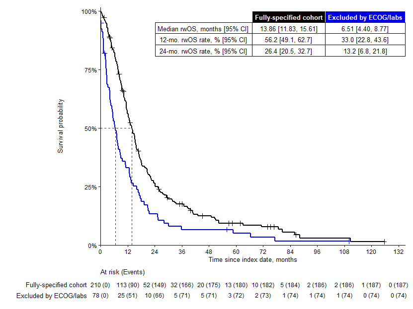

## PFS Comparison

### rwPFS - Broad Cohort Stratified by I/E status

|  | Overall Broad cohort (N=283) | Inclusion/exclusion status Fully-specified cohort (N=209) | Inclusion/exclusion status Excluded by ECOG/labs (N=74) |
| --- | --- | --- | --- |
| Status |  |  |  |
| Disease Progression | 181 (64.0%) | 141 (67.5%) | 40 (54.1%) |
| Deceased Without Progression | 47 (16.6%) | 25 (12.0%) | 22 (29.7%) |
| Censored | 55 (19.4%) | 43 (20.6%) | 12 (16.2%) |
| PFS quantiles, months [95% CI] |  |  |  |
| 25th percentile | 2.43 [2.17, 2.79] | 2.76 [2.23, 3.02] | 1.87 [1.25, 2.40] |
| Median | 4.80 [4.11, 5.59] | 5.59 [4.76, 7.85] | 3.55 [2.56, 4.34] |
| 75th percentile | 10.02 [8.77, 12.35] | 10.94 [9.69, 14.36] | 5.72 [4.37, 7.20] |
| Survival rate [95% CI] |  |  |  |
| 3 months | 66.3% [60.3%, 71.6%] | 70.3% [63.4%, 76.1%] | 54.3% [41.7%, 65.3%] |
| 6 months | 42.4% [36.2%, 48.4%] | 49.2% [41.9%, 56.2%] | 22.4% [13.1%, 33.4%] |
| 9 months | 28.1% [22.4%, 34.0%] | 33.7% [26.7%, 40.9%] | 12.1% [5.4%, 21.7%] |
| 12 months | 20.1% [15.1%, 25.7%] | 23.0% [16.8%, 29.7%] | 12.1% [5.4%, 21.7%] |
| 18 months | 12.4% [8.4%, 17.3%] | 14.0% [9.0%, 20.0%] | 8.1% [2.8%, 17.0%] |
| 2 years | 8.3% [5.0%, 12.6%] | 9.8% [5.7%, 15.2%] | 4.0% [0.8%, 11.9%] |
| 3 years | 5.2% [2.7%, 8.9%] | 5.6% [2.6%, 10.1%] | 4.0% [0.8%, 11.9%] |
| 4 years | 4.6% [2.3%, 8.2%] | 4.8% [2.1%, 9.2%] | 4.0% [0.8%, 11.9%] |
| 5 years | 3.8% [1.7%, 7.4%] | 4.8% [2.1%, 9.2%] | NA [NA, NA] |
| 6 years | 2.9% [1.0%, 6.5%] | 3.6% [1.2%, 8.0%] | NA [NA, NA] |
| 7 years | 2.9% [1.0%, 6.5%] | 3.6% [1.2%, 8.0%] | NA [NA, NA] |
| 8 years | 1.9% [0.5%, 5.5%] | 2.4% [0.6%, 6.8%] | NA [NA, NA] |
| 9 years | 1.9% [0.5%, 5.5%] | 2.4% [0.6%, 6.8%] | NA [NA, NA] |
| 10 years | 1.9% [0.5%, 5.5%] | 2.4% [0.6%, 6.8%] | NA [NA, NA] |

NR: not reached. NE: not estimable. NA: no patients at risk at this time

### rwPFS - Broad Cohort Stratified by I/E status, Truncated

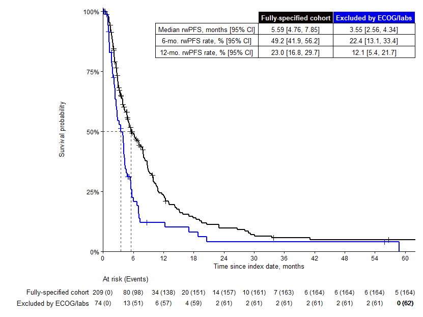

# FULL-SPEC RW COHORT

## Characteristics

| Characteristic | Overall Overall (N=210) | 1L regimen Gem/Carbo (N=68) | 1L regimen nab-Pac (N=79) | 1L regimen Pac (N=63) | All Taxane Pac + nab-Pac (N=142) |
| --- | --- | --- | --- | --- | --- |
| Age at 1L start date |  |  |  |  |  |
| Mean (SD) | 61.6 (12.6) | 56.2 (13.9) | 63.7 (11.1) | 64.7 (11.3) | 64.2 (11.1) |
| Median (IQR) | 62.0 (52.2-71.4) | 54.5 (48.0-68.0) | 65.5 (58.3-71.5) | 64.9 (57.6-72.8) | 65.0 (57.6-71.9) |
| Min-Max | 30.0-84.8 | 30.0-84.3 | 37.7-84.8 | 39.6-84.7 | 37.7-84.8 |
| Age Group 1 [at 1L start] |  |  |  |  |  |
| < 65 | 120 (57.1%) | 49 (72.1%) | 39 (49.4%) | 32 (50.8%) | 71 (50.0%) |
| >= 65 | 90 (42.9%) | 19 (27.9%) | 40 (50.6%) | 31 (49.2%) | 71 (50.0%) |
| Age Group 2 [at 1L start] |  |  |  |  |  |
| 18-35 years | 6 (2.9%) | 6 (8.8%) | 0 (0%) | 0 (0%) | 0 (0%) |
| 36-45 years | 19 (9.0%) | 9 (13.2%) | 7 (8.9%) | 3 (4.8%) | 10 (7.0%) |
| 46-55 years | 41 (19.5%) | 22 (32.4%) | 9 (11.4%) | 10 (15.9%) | 19 (13.4%) |
| 56-65 years | 59 (28.1%) | 13 (19.1%) | 26 (32.9%) | 20 (31.7%) | 46 (32.4%) |
| 66-74 years | 48 (22.9%) | 10 (14.7%) | 22 (27.8%) | 16 (25.4%) | 38 (26.8%) |
| 75 years or older | 37 (17.6%) | 8 (11.8%) | 15 (19.0%) | 14 (22.2%) | 29 (20.4%) |
| Sex |  |  |  |  |  |
| F | 209 (99.5%) | 68 (100%) | 78 (98.7%) | 63 (100%) | 141 (99.3%) |
| M | 1 (0.5%) | 0 (0%) | 1 (1.3%) | 0 (0%) | 1 (0.7%) |
| Race Group |  |  |  |  |  |
| Asian | 6 (2.9%) | 1 (1.5%) | 3 (3.8%) | 2 (3.2%) | 5 (3.5%) |
| Black or African American | 50 (23.8%) | 17 (25.0%) | 20 (25.3%) | 13 (20.6%) | 33 (23.2%) |
| White | 115 (54.8%) | 38 (55.9%) | 40 (50.6%) | 37 (58.7%) | 77 (54.2%) |
| Other | 20 (9.5%) | 4 (5.9%) | 11 (13.9%) | 5 (7.9%) | 16 (11.3%) |
| Not Reported | 19 (9.0%) | 8 (11.8%) | 5 (6.3%) | 6 (9.5%) | 11 (7.7%) |
| Ethnicity |  |  |  |  |  |
| HISPANIC OR LATINO | 12 (5.7%) | 4 (5.9%) | 5 (6.3%) | 3 (4.8%) | 8 (5.6%) |
| NOT HISPANIC OR LATINO | 159 (75.7%) | 51 (75.0%) | 64 (81.0%) | 44 (69.8%) | 108 (76.1%) |
| NOT REPORTED | 39 (18.6%) | 13 (19.1%) | 10 (12.7%) | 16 (25.4%) | 26 (18.3%) |
| Socioeconomic Index |  |  |  |  |  |
| 1 - Lowest SES | 39 (18.6%) | 10 (14.7%) | 16 (20.3%) | 13 (20.6%) | 29 (20.4%) |
| 2 | 38 (18.1%) | 8 (11.8%) | 18 (22.8%) | 12 (19.0%) | 30 (21.1%) |

[output cut: 175 more lines]

¹ Insurance types are not mutually-exclusive. ² All patients where stage was 'Not documented' have at least 3 months between initial and metastatic diagnosis. ³ Sites of metastasis recorded any time before index date until 30 days after index date (inclusive); sites are not mutually exclusive. ⁴ Closest ECOG to index date, in the period 90 days pre-index date until 7 days after index date (inclusive). ⁵ Closest weight to index date, in the period 30 days pre-index date until 7 days after index date (inclusive). ⁶ Closest PD-L1 result to index date, from the start of the study period until 30 days after index date (inclusive). ⁷ HER2 expression within +/-60 days of metastatic diagnosis date. ⁸ BRCA1/2 test result recorded from start of study period until 30 days after index date (inclusive). Patients with variant of unknown significance (VUS) were considered negative. ⁹ Hepatic impairment was defined as 'Normal' if bilirubin ≤ ULN and AST ≤ ULN; 'Mild' if ULN < bilirubin ≤ 1.5×ULN; 'Moderate' if 1.5×ULN < bilirubin ≤ 3×ULN; 'Severe' if bilirubin > 3×ULN.

## Treatment patterns

### 1L-5L Summary

|  | 1L (N=210) | 2L (N=149) | 3L (N=88) | 4L (N=50) | 5L (N=30) |
| --- | --- | --- | --- | --- | --- |
| Year LoT started |  |  |  |  |  |
| 2011 | 7 (3.3%) | 2 (1.3%) | 1 (1.1%) | 0 (0%) | 0 (0%) |
| 2012 | 10 (4.8%) | 7 (4.7%) | 1 (1.1%) | 0 (0%) | 0 (0%) |
| 2013 | 17 (8.1%) | 6 (4.0%) | 6 (6.8%) | 2 (4.0%) | 0 (0%) |
| 2014 | 25 (11.9%) | 15 (10.1%) | 9 (10.2%) | 5 (10.0%) | 3 (10.0%) |
| 2015 | 34 (16.2%) | 24 (16.1%) | 15 (17.0%) | 9 (18.0%) | 5 (16.7%) |
| 2016 | 19 (9.0%) | 16 (10.7%) | 6 (6.8%) | 4 (8.0%) | 3 (10.0%) |
| 2017 | 38 (18.1%) | 20 (13.4%) | 11 (12.5%) | 4 (8.0%) | 3 (10.0%) |
| 2018 | 29 (13.8%) | 20 (13.4%) | 13 (14.8%) | 7 (14.0%) | 4 (13.3%) |
| 2019 | 27 (12.9%) | 21 (14.1%) | 13 (14.8%) | 6 (12.0%) | 3 (10.0%) |
| 2020 | 4 (1.9%) | 13 (8.7%) | 6 (6.8%) | 3 (6.0%) | 1 (3.3%) |
| 2021 | 0 (0%) | 4 (2.7%) | 2 (2.3%) | 5 (10.0%) | 5 (16.7%) |
| 2022 | 0 (0%) | 1 (0.7%) | 4 (4.5%) | 3 (6.0%) | 2 (6.7%) |
| 2023 | 0 (0%) | 0 (0%) | 0 (0%) | 1 (2.0%) | 0 (0%) |
| 2024 | 0 (0%) | 0 (0%) | 1 (1.1%) | 1 (2.0%) | 1 (3.3%) |
| Status at end of LoT |  |  |  |  |  |
| Had next LoT | 149 (71.0%) | 88 (59.1%) | 50 (56.8%) | 30 (60.0%) | 16 (53.3%) |
| Died without next LoT | 51 (24.3%) | 54 (36.2%) | 35 (39.8%) | 19 (38.0%) | 13 (43.3%) |
| Alive without next LoT | 10 (4.8%) | 7 (4.7%) | 3 (3.4%) | 1 (2.0%) | 1 (3.3%) |
| Time to start of next LoT, months¹ |  |  |  |  |  |
| N | 149 | 88 | 50 | 30 | 16 |
| Mean (SD) | 7.6 (8.8) | 6.2 (6.8) | 6.0 (5.5) | 3.8 (2.9) | 4.3 (2.6) |
| Median (IQR) | 4.4 (2.8-9.2) | 3.5 (2.3-6.8) | 3.8 (2.5-7.4) | 3.4 (1.7-5.1) | 4.0 (1.8-6.0) |
| Min-Max | 1.0-74.4 | 1.0-34.2 | 1.4-32.1 | 1.0-15.7 | 1.1-10.6 |
| Treatment category² |  |  |  |  |  |
| Chemo | 210 (100%) | 114 (76.5%) | 67 (76.1%) | 38 (76.0%) | 21 (70.0%) |
| Chemo,IO | 0 (0%) | 10 (6.7%) | 4 (4.5%) | 2 (4.0%) | 0 (0%) |
| Chemo,Other | 0 (0%) | 6 (4.0%) | 5 (5.7%) | 2 (4.0%) | 4 (13.3%) |
| Chemo,SG | 0 (0%) | 0 (0%) | 1 (1.1%) | 1 (2.0%) | 0 (0%) |
| ET | 0 (0%) | 1 (0.7%) | 1 (1.1%) | 0 (0%) | 1 (3.3%) |

[output cut: 84 more lines]

¹ Among patients with next line only; censoring was not applied in this calculation. ² 'IO' = Immunotherapy; 'ET' = endocrine therapy; 'HER2' = HER2-directed agent(s); 'SG' = sacituzumab govitecan; 'Other' = clinical study drugs and all others (CDK4/6i, PARPi, bevacizumab, bicalutamide, cetuximab, enzalutamide, everolimus, lenvatinib, T-DXd, temsirolimus)

### Distribution of 1L start year - N patients by year 1L started

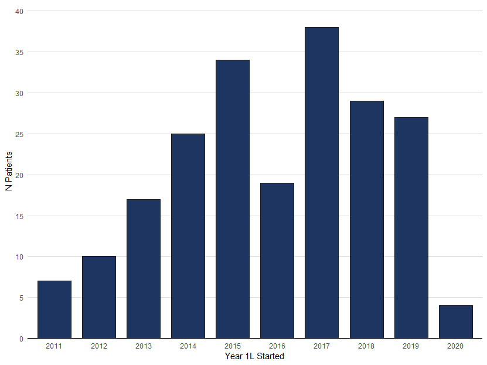

## Status after 1L

### Status after 1L by year of initiation of 1L

|  | 2011 (N=7) | 2012 (N=10) | 2013 (N=17) | 2014 (N=25) | 2015 (N=34) | 2016 (N=19) | 2017 (N=38) | 2018 (N=29) | 2019 (N=27) | 2020 (N=4) | Overall (N=210) |
| --- | --- | --- | --- | --- | --- | --- | --- | --- | --- | --- | --- |
| Status at end of 1L |  |  |  |  |  |  |  |  |  |  |  |
| Had 2L | 5 (71.4%) | 7 (70.0%) | 14 (82.4%) | 17 (68.0%) | 20 (58.8%) | 13 (68.4%) | 29 (76.3%) | 22 (75.9%) | 19 (70.4%) | 3 (75.0%) | 149 (71.0%) |
| Died without 2L | 1 (14.3%) | 2 (20.0%) | 3 (17.6%) | 7 (28.0%) | 13 (38.2%) | 5 (26.3%) | 8 (21.1%) | 4 (13.8%) | 7 (25.9%) | 1 (25.0%) | 51 (24.3%) |
| Alive without 2L | 1 (14.3%) | 1 (10.0%) | 0 (0%) | 1 (4.0%) | 1 (2.9%) | 1 (5.3%) | 1 (2.6%) | 3 (10.3%) | 1 (3.7%) | 0 (0%) | 10 (4.8%) |

### Proportion who started 2L by year of 1L initiation

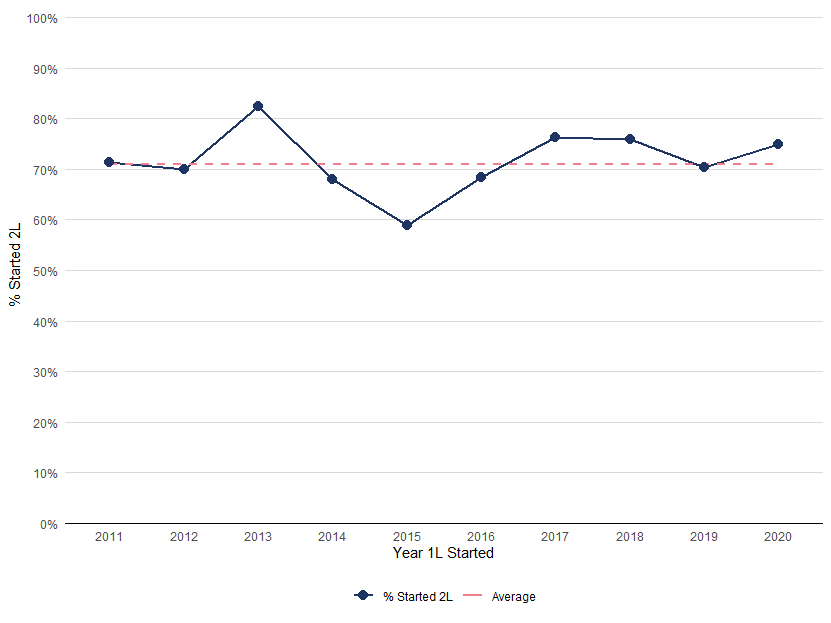

## rwOS

### rwOS - Overall and Stratified by 1L

|  | Overall Overall (N=210) | 1L regimen Gem/Carbo (N=68) | 1L regimen nab-Pac (N=79) | 1L regimen Pac (N=63) | All Taxane Pac + nab-Pac (N=142) |
| --- | --- | --- | --- | --- | --- |
| Status |  |  |  |  |  |
| Deceased | 187 (89.0%) | 63 (92.6%) | 67 (84.8%) | 57 (90.5%) | 124 (87.3%) |
| Censored | 23 (11.0%) | 5 (7.4%) | 12 (15.2%) | 6 (9.5%) | 18 (12.7%) |
| OS quantiles, months [95% CI] |  |  |  |  |  |
| 25th percentile | 7.69 [6.41, 8.97] | 6.87 [4.70, 8.57] | 8.97 [7.52, 11.40] | 5.82 [3.19, 10.64] | 8.21 [6.28, 10.25] |
| Median | 13.86 [11.83, 15.61] | 11.86 [9.10, 15.41] | 15.18 [11.73, 18.46] | 14.92 [10.64, 17.94] | 14.98 [12.29, 17.48] |
| 75th percentile | 24.28 [20.73, 31.61] | 20.73 [15.61, 29.34] | 36.93 [22.18, 50.63] | 23.56 [17.94, 29.83] | 27.40 [22.18, 39.72] |
| Survival rate [95% CI] |  |  |  |  |  |
| 3 months | 92.8% [88.4%, 95.6%] | 92.6% [83.2%, 96.9%] | 96.2% [88.6%, 98.8%] | 88.9% [78.1%, 94.5%] | 92.9% [87.3%, 96.1%] |
| 6 months | 82.2% [76.3%, 86.8%] | 80.7% [69.1%, 88.3%] | 89.7% [80.5%, 94.7%] | 74.5% [61.8%, 83.5%] | 82.9% [75.6%, 88.2%] |
| 9 months | 69.1% [62.3%, 74.9%] | 62.8% [50.1%, 73.1%] | 74.1% [62.8%, 82.5%] | 69.6% [56.6%, 79.4%] | 72.1% [63.8%, 78.8%] |
| 12 months | 56.2% [49.1%, 62.7%] | 49.3% [36.9%, 60.6%] | 59.6% [47.8%, 69.6%] | 59.5% [46.2%, 70.6%] | 59.5% [50.8%, 67.2%] |
| 18 months | 35.1% [28.5%, 41.7%] | 26.6% [16.7%, 37.6%] | 41.1% [30.0%, 51.8%] | 36.8% [24.7%, 48.9%] | 39.2% [31.0%, 47.3%] |
| 2 years | 26.4% [20.5%, 32.7%] | 20.4% [11.6%, 30.8%] | 33.1% [22.9%, 43.7%] | 24.5% [14.4%, 36.1%] | 29.4% [22.0%, 37.2%] |
| 3 years | 17.6% [12.6%, 23.2%] | 11.0% [4.8%, 19.9%] | 26.3% [16.9%, 36.6%] | 13.8% [6.4%, 24.1%] | 20.8% [14.4%, 28.1%] |
| 4 years | 12.4% [8.2%, 17.5%] | 9.4% [3.8%, 18.0%] | 16.6% [8.9%, 26.3%] | 9.9% [3.8%, 19.4%] | 13.7% [8.3%, 20.4%] |
| 5 years | 9.3% [5.6%, 14.1%] | 7.8% [2.9%, 16.0%] | 14.7% [7.5%, 24.3%] | 3.9% [0.7%, 11.8%] | 9.8% [5.2%, 16.0%] |
| 6 years | 7.7% [4.3%, 12.4%] | 7.8% [2.9%, 16.0%] | 10.5% [4.3%, 19.8%] | 3.9% [0.7%, 11.8%] | 7.3% [3.4%, 13.4%] |
| 7 years | 5.5% [2.5%, 10.3%] | 7.8% [2.9%, 16.0%] | 7.0% [1.8%, 17.2%] | NA [NA, NA] | 3.7% [0.9%, 10.0%] |
| 8 years | 3.0% [0.8%, 7.9%] | 3.9% [0.5%, 14.0%] | 3.5% [0.3%, 13.8%] | NA [NA, NA] | 1.8% [0.2%, 8.0%] |
| 9 years | 3.0% [0.8%, 7.9%] | 3.9% [0.5%, 14.0%] | 3.5% [0.3%, 13.8%] | NA [NA, NA] | 1.8% [0.2%, 8.0%] |
| 10 years | 1.5% [0.2%, 6.4%] | NA [NA, NA] | 3.5% [0.3%, 13.8%] | NA [NA, NA] | 1.8% [0.2%, 8.0%] |

NR: not reached. NE: not estimable. NA: no patients at risk at this time

### rwOS - Stratified by 1L GemCarbo/nab-Pac/Pac

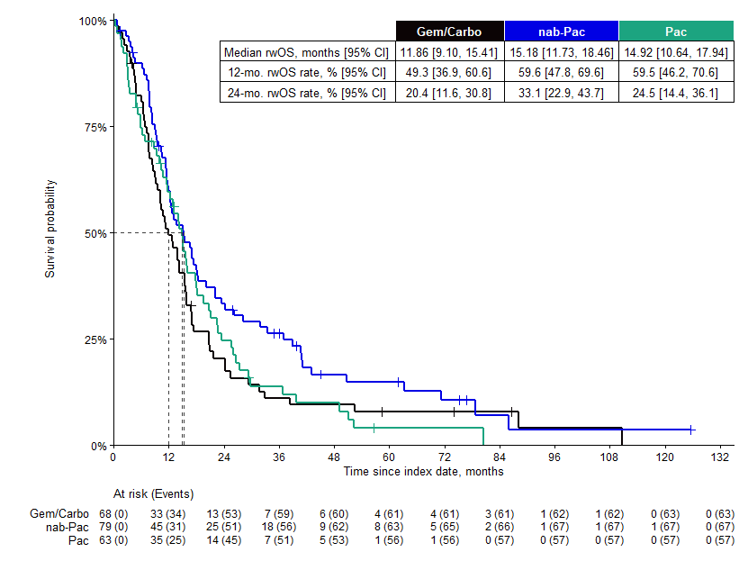

### rwOS - Stratified by 1L GemCarbo/Taxane

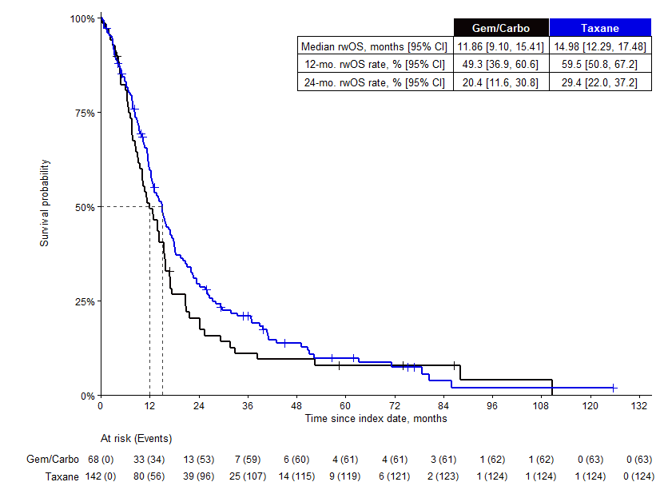

## rwPFS

### rwPFS - Overall and Stratified by 1L

|  | Overall Overall (N=209) | 1L regimen Gem/Carbo (N=68) | 1L regimen nab-Pac (N=79) | 1L regimen Pac (N=62) | All Taxane Pac + nab-Pac (N=141) |
| --- | --- | --- | --- | --- | --- |
| Status |  |  |  |  |  |
| Disease Progression | 141 (67.5%) | 50 (73.5%) | 55 (69.6%) | 36 (58.1%) | 91 (64.5%) |
| Deceased Without Progression | 25 (12.0%) | 4 (5.9%) | 8 (10.1%) | 13 (21.0%) | 21 (14.9%) |
| Censored | 43 (20.6%) | 14 (20.6%) | 16 (20.3%) | 13 (21.0%) | 29 (20.6%) |
| PFS quantiles, months [95% CI] |  |  |  |  |  |
| 25th percentile | 2.76 [2.23, 3.02] | 2.56 [2.04, 3.45] | 3.06 [2.23, 4.44] | 2.76 [1.74, 3.02] | 2.83 [2.23, 3.29] |
| Median | 5.59 [4.76, 7.85] | 5.16 [3.52, 7.43] | 8.05 [4.99, 10.02] | 4.80 [3.19, 7.95] | 6.24 [4.76, 8.84] |
| 75th percentile | 10.94 [9.69, 14.36] | 8.77 [7.79, 11.07] | 15.84 [10.84, 28.22] | 10.64 [7.13, 15.11] | 14.23 [10.48, 17.91] |
| Survival rate [95% CI] |  |  |  |  |  |
| 3 months | 70.3% [63.4%, 76.1%] | 66.7% [54.0%, 76.7%] | 76.6% [65.4%, 84.5%] | 65.9% [52.1%, 76.5%] | 72.0% [63.6%, 78.8%] |
| 6 months | 49.2% [41.9%, 56.2%] | 45.4% [32.8%, 57.1%] | 56.3% [44.1%, 66.9%] | 44.3% [30.7%, 57.0%] | 51.2% [42.1%, 59.5%] |
| 9 months | 33.7% [26.7%, 40.9%] | 21.0% [11.2%, 32.9%] | 44.5% [32.3%, 55.9%] | 33.5% [21.0%, 46.5%] | 39.7% [30.8%, 48.5%] |
| 12 months | 23.0% [16.8%, 29.7%] | 11.8% [4.6%, 22.7%] | 32.5% [21.4%, 44.1%] | 22.3% [11.8%, 34.8%] | 28.1% [20.1%, 36.6%] |
| 18 months | 14.0% [9.0%, 20.0%] | 7.1% [1.9%, 17.0%] | 20.5% [11.5%, 31.4%] | 12.6% [4.9%, 24.1%] | 17.1% [10.7%, 24.9%] |
| 2 years | 9.8% [5.7%, 15.2%] | 4.7% [0.9%, 13.9%] | 17.1% [8.9%, 27.6%] | 5.0% [0.9%, 14.7%] | 12.1% [6.7%, 19.2%] |
| 3 years | 5.6% [2.6%, 10.1%] | 4.7% [0.9%, 13.9%] | 8.6% [3.2%, 17.3%] | 2.5% [0.2%, 11.2%] | 6.0% [2.5%, 11.8%] |
| 4 years | 4.8% [2.1%, 9.2%] | 4.7% [0.9%, 13.9%] | 6.4% [1.9%, 14.9%] | 2.5% [0.2%, 11.2%] | 4.8% [1.7%, 10.4%] |
| 5 years | 4.8% [2.1%, 9.2%] | 4.7% [0.9%, 13.9%] | 6.4% [1.9%, 14.9%] | NA [NA, NA] | 4.8% [1.7%, 10.4%] |
| 6 years | 3.6% [1.2%, 8.0%] | 4.7% [0.9%, 13.9%] | 4.3% [0.9%, 12.3%] | NA [NA, NA] | 3.2% [0.8%, 8.8%] |
| 7 years | 3.6% [1.2%, 8.0%] | 4.7% [0.9%, 13.9%] | 4.3% [0.9%, 12.3%] | NA [NA, NA] | 3.2% [0.8%, 8.8%] |
| 8 years | 2.4% [0.6%, 6.8%] | NA [NA, NA] | 2.1% [0.2%, 9.5%] | NA [NA, NA] | 1.6% [0.2%, 7.1%] |
| 9 years | 2.4% [0.6%, 6.8%] | NA [NA, NA] | 2.1% [0.2%, 9.5%] | NA [NA, NA] | 1.6% [0.2%, 7.1%] |
| 10 years | 2.4% [0.6%, 6.8%] | NA [NA, NA] | 2.1% [0.2%, 9.5%] | NA [NA, NA] | 1.6% [0.2%, 7.1%] |

NR: not reached. NE: not estimable. NA: no patients at risk at this time

### rwPFS - Stratified by 1L GemCarbo/nab-Pac/Pac

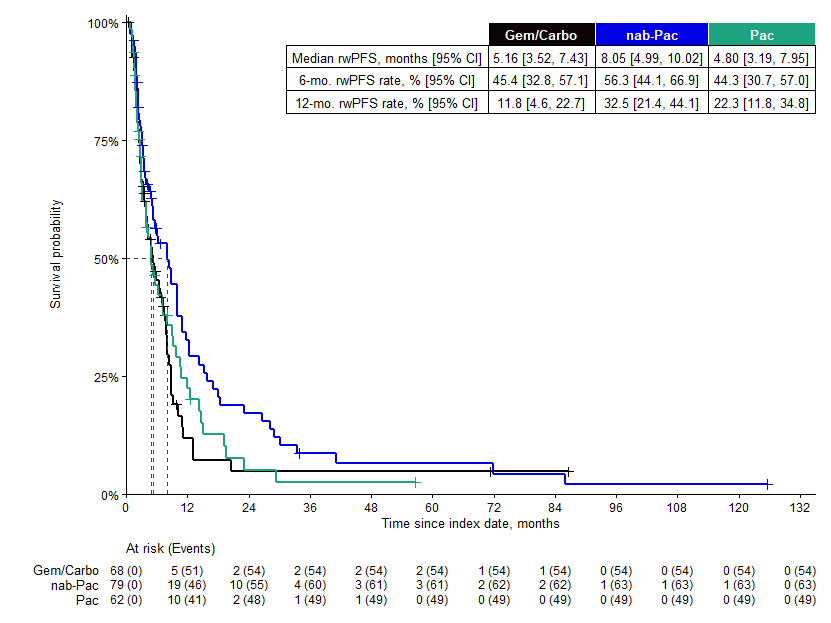

### rwPFS - Stratified by 1L GemCarbo/nab-Pac/Pac, truncated

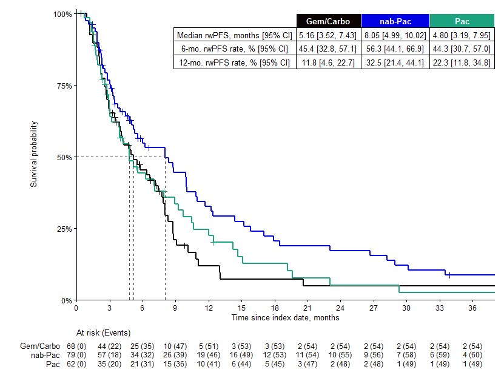

### rwPFS - Stratified by 1L GemCarbo/Taxane

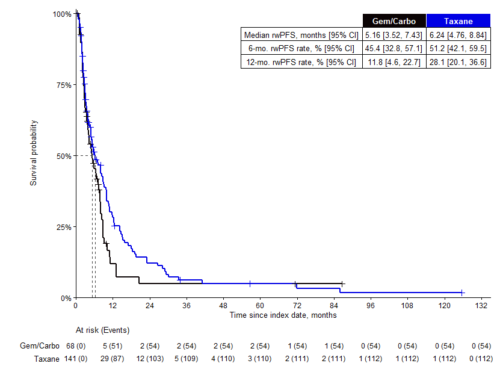

### rwPFS - Stratified by 1L GemCarbo/Taxane, truncated

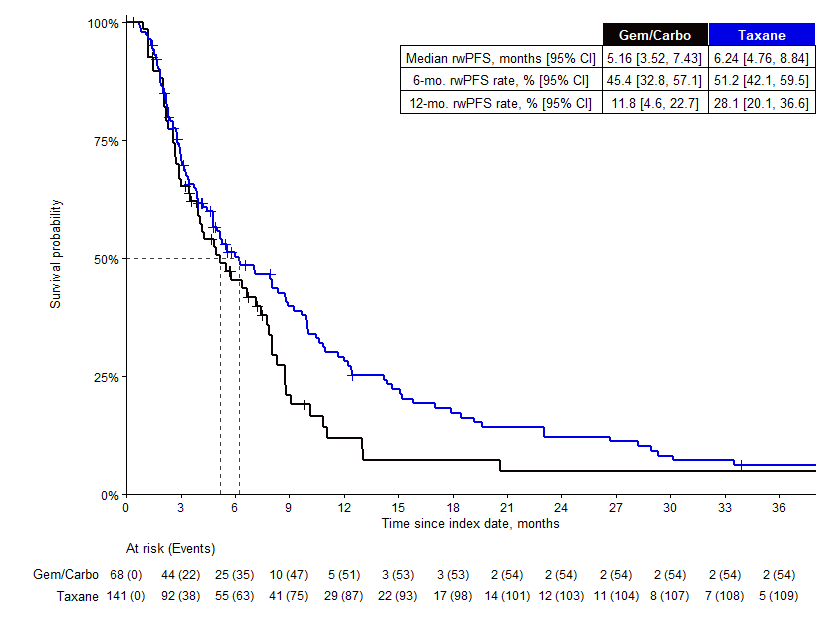

## rwTTNTD

### rwTTNTD - Overall and Stratified by 1L

|  | Overall Overall (N=210) | 1L regimen Gem/Carbo (N=68) | 1L regimen nab-Pac (N=79) | 1L regimen Pac (N=63) | All Taxane Pac + nab-Pac (N=142) |
| --- | --- | --- | --- | --- | --- |
| Status |  |  |  |  |  |
| Initiated Next Treatment | 149 (71.0%) | 49 (72.1%) | 58 (73.4%) | 42 (66.7%) | 100 (70.4%) |
| Deceased Without Next Treatment | 51 (24.3%) | 16 (23.5%) | 16 (20.3%) | 19 (30.2%) | 35 (24.6%) |
| Censored | 10 (4.8%) | 3 (4.4%) | 5 (6.3%) | 2 (3.2%) | 7 (4.9%) |
| TTNTD quantiles, months [95% CI] |  |  |  |  |  |
| 25th percentile | 2.86 [2.53, 3.25] | 2.91 [2.33, 3.55] | 3.48 [2.60, 4.07] | 2.37 [1.87, 2.99] | 2.86 [2.33, 3.48] |
| Median | 5.32 [4.34, 6.28] | 5.45 [3.81, 7.49] | 5.78 [4.34, 9.46] | 4.40 [3.19, 5.45] | 5.19 [4.24, 6.47] |
| 75th percentile | 11.33 [9.26, 13.86] | 9.36 [7.52, 12.65] | 14.59 [11.30, 28.45] | 9.66 [5.91, 15.11] | 12.39 [9.66, 16.13] |
| Survival rate [95% CI] |  |  |  |  |  |
| 3 months | 72.7% [66.2%, 78.3%] | 73.5% [61.3%, 82.4%] | 79.5% [68.8%, 86.9%] | 63.5% [50.4%, 74.0%] | 72.4% [64.2%, 79.0%] |
| 6 months | 45.2% [38.3%, 51.8%] | 48.2% [35.9%, 59.5%] | 49.7% [38.2%, 60.2%] | 36.5% [24.9%, 48.2%] | 43.8% [35.5%, 51.8%] |
| 9 months | 32.6% [26.3%, 39.0%] | 27.1% [17.1%, 38.1%] | 43.2% [32.0%, 53.9%] | 25.4% [15.5%, 36.6%] | 35.2% [27.4%, 43.1%] |
| 12 months | 23.3% [17.8%, 29.3%] | 16.6% [8.8%, 26.4%] | 32.7% [22.6%, 43.2%] | 19.0% [10.5%, 29.5%] | 26.6% [19.6%, 34.1%] |
| 18 months | 12.4% [8.4%, 17.4%] | 6.0% [1.9%, 13.5%] | 19.6% [11.6%, 29.2%] | 10.5% [4.4%, 19.7%] | 15.6% [10.1%, 22.1%] |
| 2 years | 9.5% [5.9%, 14.0%] | 4.5% [1.2%, 11.4%] | 17.0% [9.6%, 26.2%] | 5.2% [1.4%, 13.0%] | 11.8% [7.1%, 17.9%] |
| 3 years | 5.0% [2.6%, 8.6%] | 3.0% [0.6%, 9.3%] | 9.2% [4.0%, 16.9%] | 1.7% [0.1%, 8.1%] | 5.9% [2.8%, 10.8%] |
| 4 years | 3.7% [1.7%, 7.1%] | 3.0% [0.6%, 9.3%] | 5.5% [1.7%, 12.9%] | 1.7% [0.1%, 8.1%] | 3.9% [1.4%, 8.5%] |
| 5 years | 3.7% [1.7%, 7.1%] | 3.0% [0.6%, 9.3%] | 5.5% [1.7%, 12.9%] | NA [NA, NA] | 3.9% [1.4%, 8.5%] |
| 6 years | 3.7% [1.7%, 7.1%] | 3.0% [0.6%, 9.3%] | 5.5% [1.7%, 12.9%] | NA [NA, NA] | 3.9% [1.4%, 8.5%] |
| 7 years | 2.8% [1.0%, 6.3%] | 3.0% [0.6%, 9.3%] | 3.7% [0.8%, 10.6%] | NA [NA, NA] | 2.6% [0.6%, 7.2%] |
| 8 years | 1.9% [0.4%, 5.3%] | NA [NA, NA] | 1.8% [0.2%, 8.3%] | NA [NA, NA] | 1.3% [0.1%, 5.8%] |
| 9 years | 1.9% [0.4%, 5.3%] | NA [NA, NA] | 1.8% [0.2%, 8.3%] | NA [NA, NA] | 1.3% [0.1%, 5.8%] |
| 10 years | 1.9% [0.4%, 5.3%] | NA [NA, NA] | 1.8% [0.2%, 8.3%] | NA [NA, NA] | 1.3% [0.1%, 5.8%] |

NR: not reached. NE: not estimable. NA: no patients at risk at this time

### rwTTNTD - Stratified by 1L GemCarbo/nab-Pac/Pac, truncated

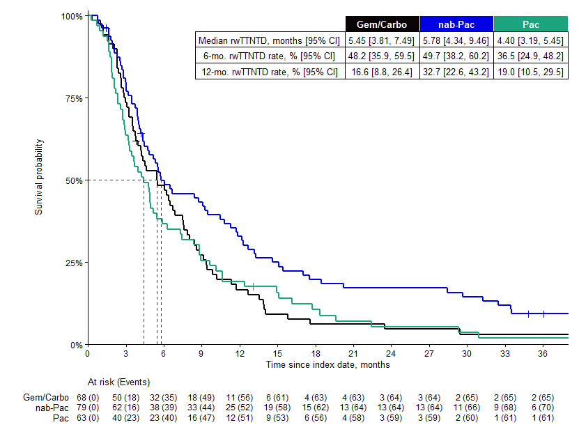

### rwTTNTD - Stratified by 1L GemCarbo/Taxane, truncated

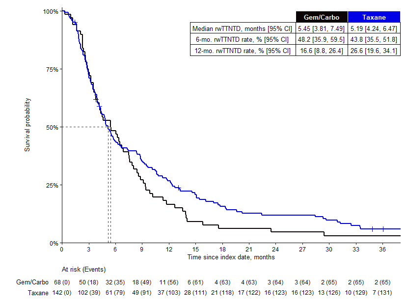

## rwTTD

### rwTTD - Overall and Stratified by 1L

|  | Overall Overall (N=210) | 1L regimen Gem/Carbo (N=68) | 1L regimen nab-Pac (N=79) | 1L regimen Pac (N=63) | All Taxane Pac + nab-Pac (N=142) |
| --- | --- | --- | --- | --- | --- |
| Status |  |  |  |  |  |
| Discontinuation | 206 (98.1%) | 67 (98.5%) | 76 (96.2%) | 63 (100%) | 139 (97.9%) |
| Censored | 4 (1.9%) | 1 (1.5%) | 3 (3.8%) | 0 (0%) | 3 (2.1%) |
| TTD quantiles, months [95% CI] |  |  |  |  |  |
| 25th percentile | 1.87 [1.41, 2.10] | 2.10 [1.41, 2.33] | 2.10 [1.48, 2.66] | 1.41 [0.72, 1.81] | 1.71 [1.41, 2.10] |
| Median | 3.48 [3.02, 3.94] | 3.25 [2.43, 3.98] | 4.40 [3.02, 5.26] | 3.02 [1.87, 3.71] | 3.52 [2.79, 4.17] |
| 75th percentile | 6.08 [5.26, 7.39] | 5.06 [4.07, 6.70] | 8.11 [5.78, 11.76] | 5.78 [3.75, 7.16] | 6.24 [5.32, 8.11] |
| Survival rate [95% CI] |  |  |  |  |  |
| 3 months | 57.5% [50.5%, 63.9%] | 55.9% [43.3%, 66.7%] | 63.0% [51.3%, 72.6%] | 52.4% [39.4%, 63.8%] | 58.3% [49.7%, 65.9%] |
| 6 months | 25.5% [19.8%, 31.6%] | 22.8% [13.6%, 33.4%] | 30.3% [20.5%, 40.7%] | 22.2% [12.9%, 33.1%] | 26.8% [19.7%, 34.3%] |
| 9 months | 12.7% [8.6%, 17.7%] | 9.1% [3.7%, 17.5%] | 21.1% [12.8%, 30.8%] | 6.3% [2.0%, 14.2%] | 14.5% [9.2%, 20.8%] |
| 12 months | 7.8% [4.7%, 12.0%] | 6.1% [2.0%, 13.6%] | 14.5% [7.7%, 23.3%] | 1.6% [0.1%, 7.5%] | 8.7% [4.7%, 14.1%] |
| 18 months | 3.4% [1.5%, 6.6%] | 1.5% [0.1%, 7.2%] | 7.9% [3.2%, 15.3%] | NA [NA, NA] | 4.3% [1.8%, 8.7%] |
| 2 years | 2.5% [0.9%, 5.3%] | NA [NA, NA] | 6.6% [2.4%, 13.6%] | NA [NA, NA] | 3.6% [1.4%, 7.7%] |
| 3 years | 1.0% [0.2%, 3.2%] | NA [NA, NA] | 2.6% [0.5%, 8.2%] | NA [NA, NA] | 1.4% [0.3%, 4.7%] |
| 4 years | 1.0% [0.2%, 3.2%] | NA [NA, NA] | 2.6% [0.5%, 8.2%] | NA [NA, NA] | 1.4% [0.3%, 4.7%] |
| 5 years | 1.0% [0.2%, 3.2%] | NA [NA, NA] | 2.6% [0.5%, 8.2%] | NA [NA, NA] | 1.4% [0.3%, 4.7%] |
| 6 years | 1.0% [0.2%, 3.2%] | NA [NA, NA] | 2.6% [0.5%, 8.2%] | NA [NA, NA] | 1.4% [0.3%, 4.7%] |
| 7 years | 0.5% [0.0%, 2.5%] | NA [NA, NA] | 1.3% [0.1%, 6.3%] | NA [NA, NA] | 0.7% [0.1%, 3.6%] |
| 8 years | 0.5% [0.0%, 2.5%] | NA [NA, NA] | 1.3% [0.1%, 6.3%] | NA [NA, NA] | 0.7% [0.1%, 3.6%] |
| 9 years | 0.5% [0.0%, 2.5%] | NA [NA, NA] | 1.3% [0.1%, 6.3%] | NA [NA, NA] | 0.7% [0.1%, 3.6%] |
| 10 years | 0.5% [0.0%, 2.5%] | NA [NA, NA] | 1.3% [0.1%, 6.3%] | NA [NA, NA] | 0.7% [0.1%, 3.6%] |

NR: not reached. NE: not estimable. NA: no patients at risk at this time

### rwTTD - Stratified by 1L GemCarbo/nab-Pac/Pac, truncated

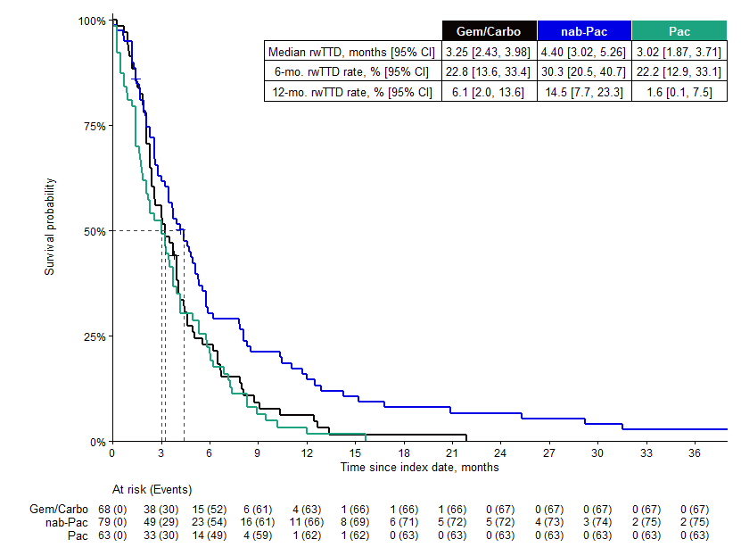

### rwTTD - Stratified by 1L GemCarbo/Taxane, truncated

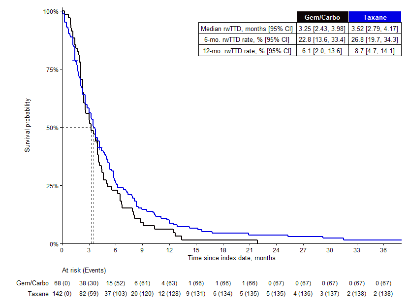

# RW SG-TREATED PATIENTS

## Characteristics SG pts

### SG-treated vs. Not SG-treated

| Characteristic | Received SG (N=15) | Not treated with SG (N=195) |
| --- | --- | --- |
| Sex |  |  |
| F | 15 (100%) | 194 (99.5%) |
| M | 0 (0%) | 1 (0.5%) |
| Age at 1L start date |  |  |
| Mean (SD) | 55.3 (11.6) | 62.1 (12.6) |
| Median (IQR) | 55.9 (49.9-65.5) | 62.0 (52.8-71.8) |
| Min-Max | 33.2-69.8 | 30.0-84.8 |
| Age Group 1 [at 1L start] |  |  |
| < 65 | 11 (73.3%) | 109 (55.9%) |
| >= 65 | 4 (26.7%) | 86 (44.1%) |
| Age Group 2 [at 1L start] |  |  |
| 18-35 years | 1 (6.7%) | 5 (2.6%) |
| 36-45 years | 2 (13.3%) | 17 (8.7%) |
| 46-55 years | 5 (33.3%) | 36 (18.5%) |
| 56-65 years | 3 (20.0%) | 56 (28.7%) |
| 66-74 years | 4 (26.7%) | 44 (22.6%) |
| 75 years or older | 0 (0%) | 37 (19.0%) |
| Race Group |  |  |
| Asian | 0 (0%) | 6 (3.1%) |
| Black or African American | 3 (20.0%) | 47 (24.1%) |
| White | 9 (60.0%) | 106 (54.4%) |
| Other | 1 (6.7%) | 19 (9.7%) |
| Not Reported | 2 (13.3%) | 17 (8.7%) |
| Time to Death/Last Alive from 1L |  |  |
| N | 15 | 195 |
| Mean (SD) | 45.4 (28.1) | 17.8 (18.6) |
| Median (IQR) | 39.0 (25.1-56.2) | 12.3 (7.0-20.8) |
| Min-Max | 10.6-110.7 | 0.3-125.6 |
| Disease Stage at Initial Diagnosis |  |  |
| STAGE 1 | 2 (13.3%) | 29 (14.9%) |

[output cut: 88 more lines]

### SG-specific characteristics of SG-treated patients

| Characteristic | SG-Treated (N=15) |
| --- | --- |
| Age at SG start date |  |
| Mean (SD) | 58.0 (12.1) |
| Median (IQR) | 61.2 (51.1-68.2) |
| Min-Max | 34.0-72.6 |
| Age group at SG start |  |
| 18-35 years | 1 (6.7%) |
| 36-45 years | 2 (13.3%) |
| 46-55 years | 3 (20.0%) |
| 56-65 years | 4 (26.7%) |
| 66-74 years | 5 (33.3%) |
| Number of LoTs Prior to SG |  |
| 1 | 2 (13.3%) |
| 2 | 4 (26.7%) |
| 3 | 3 (20.0%) |
| 4 | 2 (13.3%) |
| 7 | 1 (6.7%) |
| 8 | 2 (13.3%) |
| 9 | 1 (6.7%) |
| Time from Met. to SG, mths |  |
| Mean (SD) | 34.6 (23.2) |
| Median (IQR) | 28.8 (18.9-40.4) |
| Min-Max | 9.1-85.5 |
| Time from 1L to SG, mths |  |
| Mean (SD) | 32.1 (23.9) |
| Median (IQR) | 26.8 (15.3-39.4) |
| Min-Max | 8.9-84.9 |

## rwOS - SG Comparison

### rwOS - Basic Adjustments for SG

|  | Normal Censoring (N=210) | Censored at SG (N=210) | Excl. SG-treated (N=195) |
| --- | --- | --- | --- |
| Status |  |  |  |
| Deceased | 187 (89.0%) | 175 (83.3%) | 175 (89.7%) |
| Censored | 23 (11.0%) | 20 (9.5%) | 20 (10.3%) |
| Treated with SG; Censored at SG Initiation | 0 (0%) | 15 (7.1%) | 0 (0%) |
| OS quantiles, months [95% CI] |  |  |  |
| 25th percentile | 7.69 [6.41, 8.97] | 7.69 [6.41, 8.97] | 7.52 [5.95, 8.44] |
| Median | 13.86 [11.83, 15.61] | 13.86 [11.83, 15.61] | 12.85 [11.40, 14.98] |
| 75th percentile | 24.28 [20.73, 31.61] | 25.46 [20.90, 32.82] | 22.14 [17.77, 27.40] |
| Survival rate [95% CI] |  |  |  |
| 3 months | 92.8% [88.4%, 95.6%] | 92.8% [88.4%, 95.6%] | 92.3% [87.5%, 95.3%] |
| 6 months | 82.2% [76.3%, 86.8%] | 82.2% [76.3%, 86.8%] | 80.8% [74.6%, 85.7%] |
| 9 months | 69.1% [62.3%, 74.9%] | 69.1% [62.3%, 74.9%] | 66.6% [59.5%, 72.8%] |
| 12 months | 56.2% [49.1%, 62.7%] | 56.5% [49.3%, 62.9%] | 53.3% [45.9%, 60.1%] |
| 18 months | 35.1% [28.5%, 41.7%] | 34.7% [28.1%, 41.3%] | 30.4% [23.9%, 37.1%] |
| 2 years | 26.4% [20.5%, 32.7%] | 26.5% [20.5%, 32.9%] | 22.1% [16.4%, 28.3%] |
| 3 years | 17.6% [12.6%, 23.2%] | 18.4% [13.1%, 24.3%] | 14.1% [9.5%, 19.6%] |
| 4 years | 12.4% [8.2%, 17.5%] | 13.3% [8.6%, 18.9%] | 9.6% [5.8%, 14.6%] |
| 5 years | 9.3% [5.6%, 14.1%] | 10.8% [6.5%, 16.3%] | 7.6% [4.2%, 12.3%] |
| 6 years | 7.7% [4.3%, 12.4%] | 8.8% [4.9%, 14.3%] | 5.9% [2.9%, 10.4%] |
| 7 years | 5.5% [2.5%, 10.3%] | 6.3% [2.8%, 11.8%] | 3.5% [1.2%, 8.1%] |
| 8 years | 3.0% [0.8%, 7.9%] | 4.2% [1.2%, 10.4%] | 2.4% [0.5%, 6.8%] |
| 9 years | 3.0% [0.8%, 7.9%] | 4.2% [1.2%, 10.4%] | 2.4% [0.5%, 6.8%] |
| 10 years | 1.5% [0.2%, 6.4%] | 4.2% [1.2%, 10.4%] | 2.4% [0.5%, 6.8%] |

NR: not reached. NE: not estimable. NA: no patients at risk at this time

### rwOS - Basic Adjustments for SG

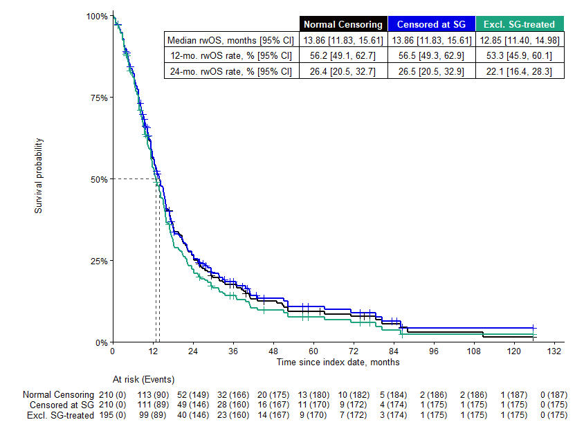

# ASC-03 OUTCOMES

- Results from A-03 are included for internal information only
- Primary analysis data cut-off was April 2, 2025
- Interim analysis 1 data cut-off was October 27, 2025
- The hazard ratios with 95% CI presented in the OS and PFS plots below were calculated using Cox proportional hazards models stratified by the stratification factors at randomization
- All results have been verified against the [published primary results](https://www.nejm.org/doi/full/10.1056/NEJMoa2511734) or the [Interim Analysis Topline TFLs](https://candid.gilead.com/1/analysis/202589/review/details/9988)

## OS - Primary

|  | A03 SG Arm (N=279) | A03 Control (N=279) |
| --- | --- | --- |
| Status |  |  |
| Deceased | 103 (36.9%) | 103 (36.9%) |
| Censored | 176 (63.1%) | 176 (63.1%) |
| OS quantiles, months [95% CI] |  |  |
| 25th percentile | 12.06 [10.15, 13.57] | 11.53 [10.48, 13.50] |
| Median | 21.45 [17.71, NE] | 20.24 [18.23, NE] |
| 75th percentile | NR [NE, NE] | NR [NE, NE] |
| Survival rate [95% CI] |  |  |
| 3 months | 97.1% [94.3%, 98.6%] | 97.1% [94.3%, 98.5%] |
| 6 months | 88.1% [83.7%, 91.4%] | 89.9% [85.6%, 92.9%] |
| 9 months | 83.4% [78.4%, 87.3%] | 84.4% [79.5%, 88.2%] |
| 12 months | 75.4% [69.8%, 80.2%] | 73.3% [67.4%, 78.2%] |
| 18 months | 56.6% [49.1%, 63.3%] | 58.3% [51.0%, 65.0%] |
| 24 months | 46.4% [36.2%, 56.0%] | 41.6% [28.9%, 53.8%] |
| 30 months | NA [NA, NA] | NA [NA, NA] |
| 36 months | NA [NA, NA] | NA [NA, NA] |

NR: not reached. NE: not estimable. NA: no patients at risk at this time

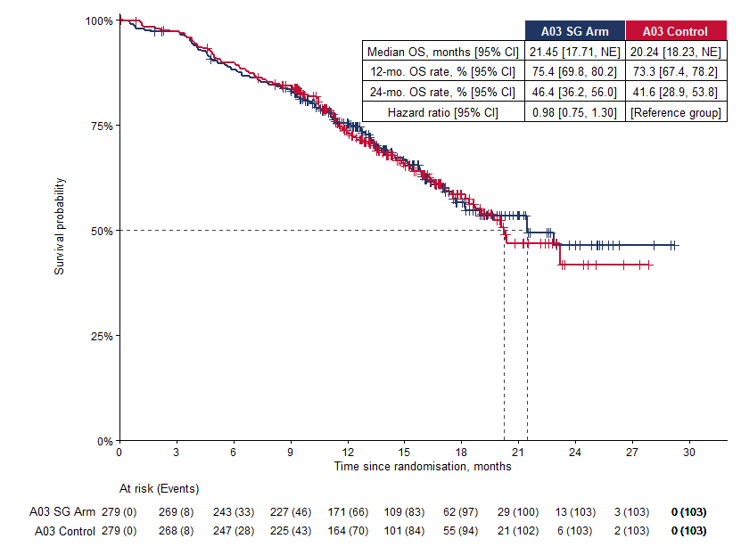

## PFS - Primary

|  | A03 SG Arm (N=279) | A03 Control (N=279) |
| --- | --- | --- |
| Status |  |  |
| Disease Progression | 143 (51.3%) | 180 (64.5%) |
| Deceased Without Progression | 18 (6.5%) | 8 (2.9%) |
| Censored | 118 (42.3%) | 91 (32.6%) |
| PFS quantiles, months [95% CI] |  |  |
| 25th percentile | 4.21 [3.88, 5.55] | 4.04 [2.83, 4.17] |
| Median | 9.69 [8.15, 11.14] | 6.93 [5.62, 8.25] |
| 75th percentile | 18.00 [15.21, 22.01] | 11.20 [9.69, 15.38] |
| Survival rate [95% CI] |  |  |
| 3 months | 85.1% [80.2%, 88.9%] | 78.6% [73.2%, 83.1%] |
| 6 months | 65.2% [59.0%, 70.8%] | 53.2% [46.9%, 59.2%] |
| 9 months | 51.9% [45.4%, 58.0%] | 35.2% [29.1%, 41.4%] |
| 12 months | 40.9% [34.3%, 47.4%] | 24.3% [18.6%, 30.4%] |
| 18 months | 26.1% [19.1%, 33.6%] | 12.7% [7.1%, 20.1%] |
| 24 months | 15.9% [8.8%, 24.8%] | NA [NA, NA] |
| 30 months | NA [NA, NA] | NA [NA, NA] |
| 36 months | NA [NA, NA] | NA [NA, NA] |

NR: not reached. NE: not estimable. NA: no patients at risk at this time

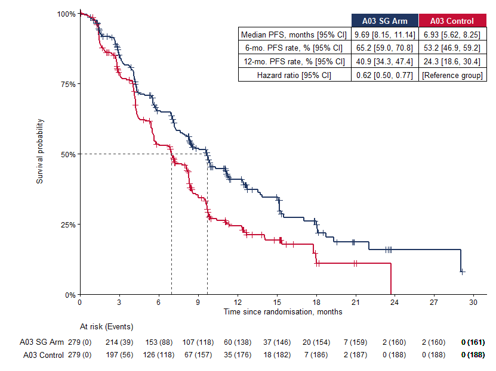

## OS - Interim 1

|  | A03 SG Arm (N=279) | A03 Control (N=279) |
| --- | --- | --- |
| Status |  |  |
| Deceased | 139 (49.8%) | 144 (51.6%) |
| Censored | 140 (50.2%) | 135 (48.4%) |
| OS quantiles, months [95% CI] |  |  |
| 25th percentile | 12.22 [10.15, 13.80] | 11.47 [10.45, 13.50] |
| Median | 21.45 [18.86, 26.55] | 21.26 [18.69, 25.17] |
| 75th percentile | NR [NE, NE] | NR [28.75, NE] |
| Survival rate [95% CI] |  |  |
| 3 months | 97.1% [94.3%, 98.6%] | 97.1% [94.3%, 98.5%] |
| 6 months | 88.1% [83.7%, 91.4%] | 89.9% [85.6%, 92.9%] |
| 9 months | 83.0% [78.1%, 87.0%] | 84.0% [79.1%, 87.9%] |
| 12 months | 75.4% [69.9%, 80.1%] | 73.3% [67.7%, 78.2%] |
| 18 months | 59.4% [53.3%, 65.0%] | 58.5% [52.3%, 64.1%] |
| 24 months | 45.2% [38.5%, 51.7%] | 45.4% [38.7%, 51.9%] |
| 30 months | 40.5% [32.5%, 48.4%] | 33.0% [23.6%, 42.7%] |
| 36 months | 40.5% [32.5%, 48.4%] | NA [NA, NA] |

NR: not reached. NE: not estimable. NA: no patients at risk at this time

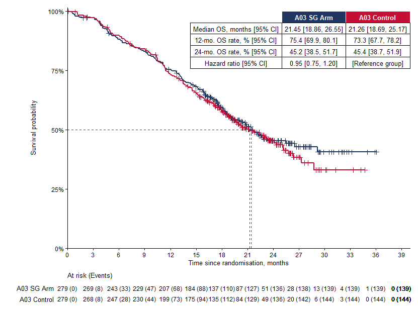

## PFS - Interim 1

|  | A03 SG Arm (N=279) | A03 Control (N=279) |
| --- | --- | --- |
| Status |  |  |
| Disease Progression | 165 (59.1%) | 194 (69.5%) |
| Deceased Without Progression | 20 (7.2%) | 9 (3.2%) |
| Censored | 94 (33.7%) | 76 (27.2%) |
| PFS quantiles, months [95% CI] |  |  |
| 25th percentile | 4.21 [3.88, 5.52] | 4.04 [2.83, 4.17] |
| Median | 9.59 [7.66, 11.14] | 6.93 [5.62, 8.25] |
| 75th percentile | 17.81 [15.21, 18.73] | 11.33 [9.72, 14.06] |
| Survival rate [95% CI] |  |  |
| 3 months | 85.0% [80.1%, 88.8%] | 78.6% [73.2%, 83.1%] |
| 6 months | 65.1% [58.8%, 70.6%] | 53.2% [46.9%, 59.2%] |
| 9 months | 50.6% [44.1%, 56.7%] | 35.5% [29.4%, 41.7%] |
| 12 months | 41.4% [35.0%, 47.6%] | 24.0% [18.5%, 29.9%] |
| 18 months | 24.0% [18.2%, 30.2%] | 11.0% [6.9%, 16.2%] |
| 24 months | 14.6% [9.4%, 20.9%] | 5.1% [0.8%, 16.2%] |
| 30 months | 10.4% [5.0%, 18.1%] | NA [NA, NA] |
| 36 months | NA [NA, NA] | NA [NA, NA] |

NR: not reached. NE: not estimable. NA: no patients at risk at this time

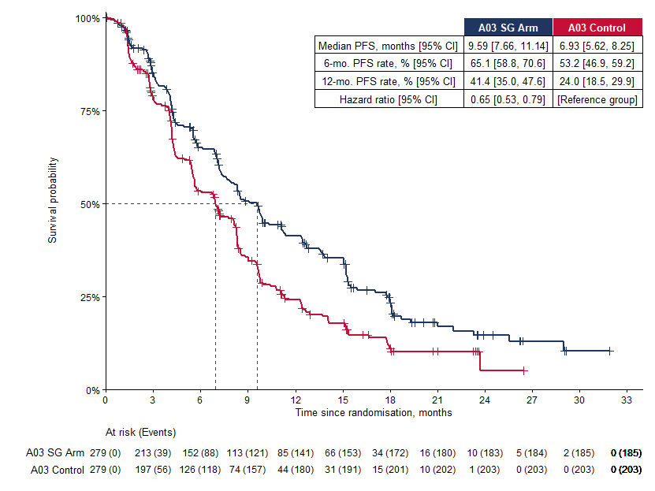

# EXTERNAL CONTROL

- All results below compare RW ECA vs the **Primary Analysis** of ASCENT-03

## Characteristics

| Characteristic | External Control RWD (N=210) | ASCENT-03 All A-03 All (N=558) | ASCENT-03 by Arm A03 SG Arm (N=279) | ASCENT-03 by Arm A03 Control (N=279) |
| --- | --- | --- | --- | --- |
| Sex |  |  |  |  |
| F | 209 (99.5%) | 555 (99.5%) | 278 (99.6%) | 277 (99.3%) |
| M | 1 (0.5%) | 3 (0.5%) | 1 (0.4%) | 2 (0.7%) |
| Age at 1L start date |  |  |  |  |
| Mean (SD) | 61.6 (12.6) | 55.3 (12.6) | 55.7 (11.9) | 54.9 (13.3) |
| Median (IQR) | 62.0 (52.2-71.4) | 55.0 (46.0-65.0) | 56.0 (46.5-64.0) | 54.0 (44.5-65.5) |
| Min-Max | 30.0-84.8 | 23.0-86.0 | 28.0-84.0 | 23.0-86.0 |
| Age Group 1 [at 1L start] |  |  |  |  |
| < 65 | 120 (57.1%) | 415 (74.4%) | 214 (76.7%) | 201 (72.0%) |
| >= 65 | 90 (42.9%) | 143 (25.6%) | 65 (23.3%) | 78 (28.0%) |
| Geographic Region |  |  |  |  |
| US/Canada/Western Europe | 210 (100%) | 178 (31.9%) | 89 (31.9%) | 89 (31.9%) |
| Rest of the World | 0 (0%) | 380 (68.1%) | 190 (68.1%) | 190 (68.1%) |
| Race Group |  |  |  |  |
| Asian | 6 (2.9%) | 131 (23.5%) | 66 (23.7%) | 65 (23.3%) |
| Black or African American | 50 (23.8%) | 17 (3.0%) | 10 (3.6%) | 7 (2.5%) |
| White | 115 (54.8%) | 356 (63.8%) | 178 (63.8%) | 178 (63.8%) |
| Other | 20 (9.5%) | 46 (8.2%) | 20 (7.2%) | 26 (9.3%) |
| Not Reported | 19 (9.0%) | 8 (1.4%) | 5 (1.8%) | 3 (1.1%) |
| Ethnicity |  |  |  |  |
| HISPANIC OR LATINO | 12 (5.7%) | 150 (26.9%) | 73 (26.2%) | 77 (27.6%) |
| NOT HISPANIC OR LATINO | 159 (75.7%) | 403 (72.2%) | 203 (72.8%) | 200 (71.7%) |
| NOT REPORTED | 39 (18.6%) | 5 (0.9%) | 3 (1.1%) | 2 (0.7%) |
| Year of Initial Diagnosis |  |  |  |  |
| Before 2000 | 7 (3.3%) | 4 (0.7%) | 1 (0.4%) | 3 (1.1%) |
| 2000-2010 | 34 (16.2%) | 24 (4.3%) | 9 (3.2%) | 15 (5.4%) |
| 2011 | 20 (9.5%) | 3 (0.5%) | 1 (0.4%) | 2 (0.7%) |
| 2012 | 14 (6.7%) | 6 (1.1%) | 5 (1.8%) | 1 (0.4%) |
| 2013 | 25 (11.9%) | 6 (1.1%) | 3 (1.1%) | 3 (1.1%) |
| 2014 | 20 (9.5%) | 4 (0.7%) | 2 (0.7%) | 2 (0.7%) |

[output cut: 144 more lines]

## Weighting Approaches

| Approach | Description/Variable selection |
| --- | --- |
| A | Sex, Age at randomization/index date, Time from diagnosis to mBC with de-novo indicator, indicators of sites of metastasis at baseline (Bone, Brain, Liver, Lung) |
| B | Same variables as Approach A + pre-randomization treatment of physician’s choice chemotherapy regimen (either Gem/Carbo, nab-Pac, or Pac) |
| C | Same variables as Approach A + Race **(weighting failed)** |
| D | Same variables as Approach A; weighting performed after first removing n=15 SG-treated patients from RW ECA |
| E | Same variables as Approach A + imputed baseline ECOG |
| F | Same variables as Approach B + imputed baseline ECOG |
| Subgroup | Split by TPC. Same variables as Approach A, except without Sex in Gem/Carbo and Paclitaxel subgroups because all pts were female in either the ECA or ASCENT-03 data |
| Trim @ XX | Large weights were capped (winsorized) at the 95th percentile weight (no observations were excluded) |

## Weighting Results

- “HR” = Hazard ratio of ASCENT-03 SG Arm vs. the approach in the row, computed by Cox proportional hazards model
- “Median” = Median time-to-event, computed by Kaplan-Meier
- For Approaches E and F involving multiple imputation:
  - No attempt was made to pool median time-to-event
  - Weights diagnostics tables are provided per imputation in the WEIGHTS DIAGNOSTICS section

| **Approach** | **Overall survival** **HR [95% CI]** | **Overall survival** **Median [95% CI]** | **Progression-free survival** **HR [95% CI]** | **Progression-free survival** **Median [95% CI]** | **Weights diagnostics** **Range** | **Weights diagnostics** **RW N Pts** | **Weights diagnostics** **ESS** | **Weights diagnostics** **Top Five** |
| --- | --- | --- | --- | --- | --- | --- | --- | --- |
| A03 SG Arm | NA | 21.45 [17.71, NE] | NA | 9.69 [8.15, 11.14] | NA | NA | NA | NA |
| A03 Control Arm | 0.98 [0.75, 1.30] | 20.24 [18.23, NE] | 0.62 [0.50, 0.77] | 6.93 [5.62, 8.25] | NA | NA | NA | NA |
| RW Unweighted | 0.54 [0.42, 0.69] | 13.86 [11.83, 15.61] | 0.64 [0.52, 0.80] | 5.59 [4.76, 7.85] | NA | NA | NA | NA |
| Approach A | 0.56 [0.42, 0.75] | 12.98 [11.43, 15.90] | 0.70 [0.53, 0.92] | 6.41 [4.80, 8.02] | 0.21-6.6 | 210 | 134.5 | 3.9, 3.9, 5.9, 6.3, 6.6 |
| Trim @ 99th | 0.56 [0.42, 0.75] | 12.98 [11.43, 15.90] | 0.70 [0.53, 0.92] | 6.41 [4.80, 8.02] | 0.21-5.9 | 210 | 136.7 | 3.9, 3.9, 5.9, 5.9, 5.9 |
| Trim @ 95th | 0.55 [0.42, 0.72] | 12.98 [11.43, 15.64] | 0.67 [0.52, 0.86] | 6.01 [4.76, 7.85] | 0.21-3.3 | 210 | 151.1 | 3.3, 3.3, 3.3, 3.3, 3.3 |
| Approach B | 0.55 [0.41, 0.73] | 12.98 [11.37, 15.77] | 0.69 [0.52, 0.91] | 6.41 [4.76, 7.95] | 0.16-7.2 | 210 | 127.4 | 4.3, 4.4, 6.5, 7.0, 7.2 |
| Trim @ 99th | 0.55 [0.41, 0.73] | 12.98 [11.37, 15.77] | 0.69 [0.52, 0.91] | 6.41 [4.76, 7.95] | 0.16-6.5 | 210 | 129.7 | 4.3, 4.4, 6.5, 6.5, 6.5 |
| Trim @ 95th | 0.54 [0.41, 0.71] | 12.98 [11.43, 15.61] | 0.65 [0.51, 0.84] | 5.78 [4.44, 7.85] | 0.16-3.2 | 210 | 149.2 | 3.2, 3.2, 3.2, 3.2, 3.2 |
| Approach C | 0.59 [0.41, 0.85] | 14.06 [10.35, 17.91] | 0.63 [0.45, 0.88] | 5.59 [3.06, 7.79] | 0.02-17.3 | 210 | 56.9 | 8.7, 10.0, 11.0, 14.4, 17.3 |
| Trim @ 99th | 0.61 [0.43, 0.86] | 14.06 [10.64, 17.91] | 0.65 [0.47, 0.90] | 6.41 [4.21, 7.95] | 0.02-11.0 | 210 | 66.0 | 8.7, 10.0, 11.0, 11.0, 11.0 |
| Trim @ 95th | 0.60 [0.44, 0.82] | 14.06 [11.79, 17.05] | 0.67 [0.50, 0.89] | 6.41 [4.76, 8.02] | 0.02-4.5 | 210 | 98.2 | 4.5, 4.5, 4.5, 4.5, 4.5 |
| Approach D | 0.51 [0.38, 0.68] | 12.65 [11.20, 14.98] | 0.72 [0.54, 0.95] | 6.41 [4.80, 8.02] | 0.22-7.1 | 195 | 121.6 | 4.3, 4.4, 6.3, 6.8, 7.1 |
| Trim @ 99th | 0.51 [0.38, 0.68] | 12.65 [11.20, 14.92] | 0.72 [0.54, 0.95] | 6.41 [4.80, 8.02] | 0.22-6.3 | 195 | 123.8 | 4.3, 4.4, 6.3, 6.3, 6.3 |
| Trim @ 95th | 0.49 [0.37, 0.65] | 12.45 [11.20, 14.32] | 0.69 [0.53, 0.89] | 6.01 [4.76, 7.95] | 0.22-3.6 | 195 | 137.5 | 3.6, 3.6, 3.6, 3.6, 3.6 |
| Approach E | 0.58 [0.45, 0.74] | NA | 0.71 [0.57, 0.88] | NA | NA | NA | NA | NA |
| Trim @ 99th | 0.58 [0.45, 0.74] | NA | 0.70 [0.57, 0.87] | NA | NA | NA | NA | NA |
| Trim @ 95th | 0.57 [0.44, 0.72] | NA | 0.68 [0.55, 0.85] | NA | NA | NA | NA | NA |
| Approach F | 0.57 [0.44, 0.72] | NA | 0.70 [0.56, 0.86] | NA | NA | NA | NA | NA |
| Trim @ 99th | 0.56 [0.44, 0.72] | NA | 0.69 [0.55, 0.85] | NA | NA | NA | NA | NA |
| Trim @ 95th | 0.56 [0.44, 0.72] | NA | 0.67 [0.54, 0.83] | NA | NA | NA | NA | NA |

## Weighting Results TPC Subgroups

- “HR” = Hazard ratio of ASCENT-03 SG Arm vs. the approach in the row, computed by Cox proportional hazards model
- “Median” = Median time-to-event, computed by Kaplan-Meier

| **Approach** | **Overall survival** **HR [95% CI]** | **Overall survival** **Median [95% CI]** | **Progression-free survival** **HR [95% CI]** | **Progression-free survival** **Median [95% CI]** | **Weights diagnostics** **Range** | **Weights diagnostics** **RW N Pts** | **Weights diagnostics** **ESS** | **Weights diagnostics** **Top Five** |
| --- | --- | --- | --- | --- | --- | --- | --- | --- |
| TPC Gem/Carbo | 0.66 [0.43, 1.01] | 13.86 [10.35, 17.02] | 0.66 [0.44, 0.99] | 6.64 [4.21, 8.05] | 0.18-4.7 | 68 | 48.4 | 3.9, 4.0, 4.1, 4.6, 4.7 |
| Trim @ 99th | 0.65 [0.43, 1.01] | 13.86 [10.35, 17.02] | 0.66 [0.44, 0.99] | 6.64 [4.21, 8.05] | 0.18-4.6 | 68 | 48.5 | 3.9, 4.0, 4.1, 4.6, 4.6 |
| Trim @ 95th | 0.64 [0.42, 0.98] | 13.86 [10.35, 17.02] | 0.66 [0.44, 0.98] | 6.64 [4.21, 8.05] | 0.18-4.0 | 68 | 49.3 | 3.9, 4.0, 4.0, 4.0, 4.0 |
| TPC nab-Pac | 0.60 [0.36, 1.00] | 15.08 [11.43, 28.22] | 0.72 [0.48, 1.08] | 6.24 [4.44, 9.95] | 0.11-6.2 | 79 | 45.0 | 2.7, 2.8, 2.8, 3.3, 6.2 |
| Trim @ 99th | 0.57 [0.35, 0.92] | 13.14 [11.40, 22.14] | 0.72 [0.47, 1.09] | 6.01 [4.44, 9.95] | 0.11-3.3 | 79 | 49.6 | 2.7, 2.8, 2.8, 3.3, 3.3 |
| Trim @ 95th | 0.57 [0.35, 0.92] | 13.14 [11.43, 22.14] | 0.72 [0.47, 1.09] | 6.01 [4.44, 9.95] | 0.11-2.7 | 79 | 50.7 | 2.7, 2.7, 2.7, 2.7, 2.7 |
| TPC Pac | 0.45 [0.23, 0.88] | 15.90 [11.79, 25.63] | 0.62 [0.33, 1.16] | 7.13 [3.84, 10.48] | 0.11-3.9 | 63 | 37.1 | 1.8, 2.0, 2.2, 3.3, 3.9 |
| Trim @ 99th | 0.45 [0.23, 0.86] | 15.90 [11.79, 23.56] | 0.60 [0.33, 1.08] | 7.13 [3.19, 9.69] | 0.11-3.3 | 63 | 38.6 | 1.8, 2.0, 2.2, 3.3, 3.3 |
| Trim @ 95th | 0.42 [0.22, 0.81] | 15.90 [11.43, 21.06] | 0.54 [0.32, 0.90] | 7.06 [3.02, 9.26] | 0.11-2.0 | 63 | 44.3 | 1.8, 2.0, 2.0, 2.0, 2.0 |

# WEIGHTED KM PLOTS - OS

- Trimmed-weight versions are not presented here, but are stored in the DARS study folder
- Approach C is omitted (model included Race)
- Kaplan-Meier plots for Approaches E and F were not created (approaches included multiple imputation)
- All OS plots have been truncated at t=60 months; all PFS plots have been truncated at t=36 months
- ‘N at risk’ table is omitted because in the wECA, this represents a weighted count rather than a count of physical patients

## Approach A

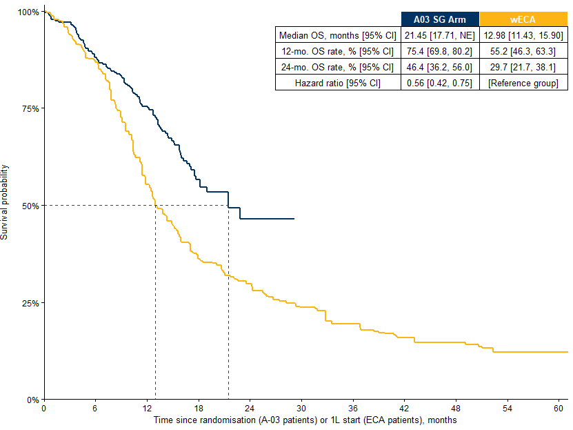

## Approach B

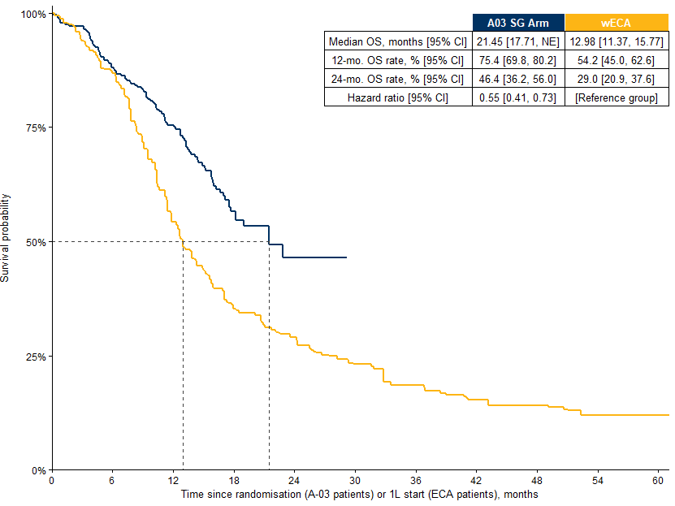

## Approach D

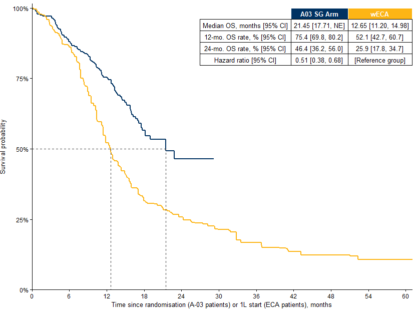

## TPC Subgroups

### Gemcitabine/Carboplatin

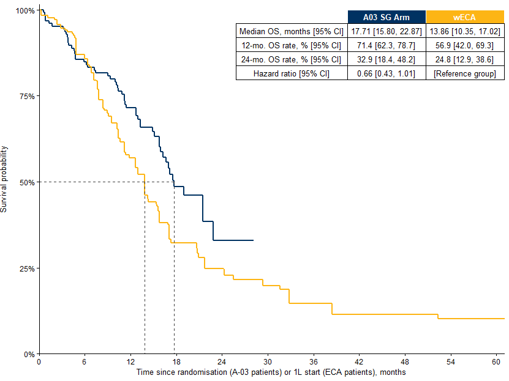

### nab-Paclitaxel

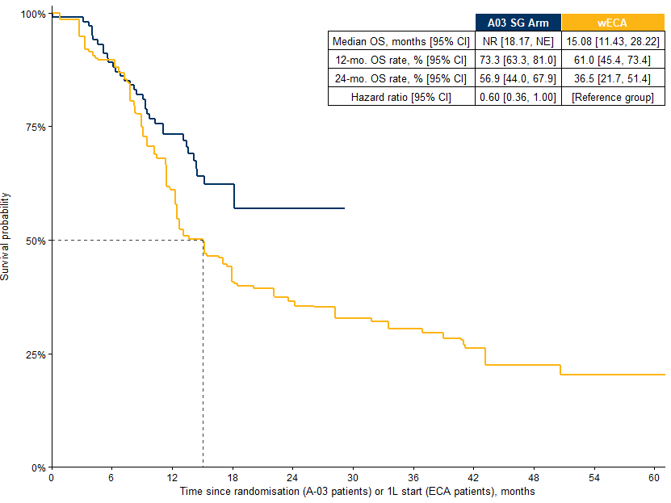

### Paclitaxel

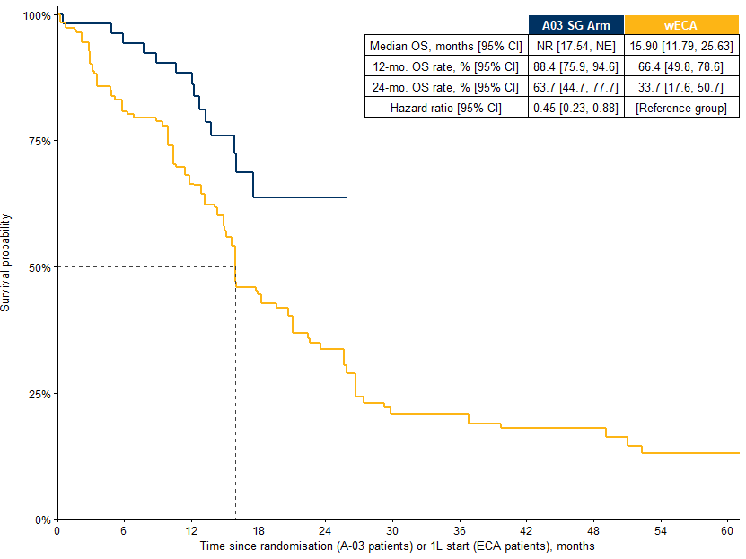

# WEIGHTED KM PLOTS - PFS

- Trimmed-weight versions are not presented here, but are stored in the DARS study folder
- Approach C is omitted (model included Race)
- Kaplan-Meier plots for Approaches E and F were not created (approaches included multiple imputation)
- All OS plots have been truncated at t=60 months; all PFS plots have been truncated at t=36 months
- ‘N at risk’ table is omitted because in the wECA, this represents a weighted count rather than a count of physical patients
- Plots showing both trial arms and wECA are included for additional context and to demonstrate similarity in PFS between weighted external cohort and actual trial control arm

## Approach A

### ASCENT-03 SG Arm vs Weighted ECA

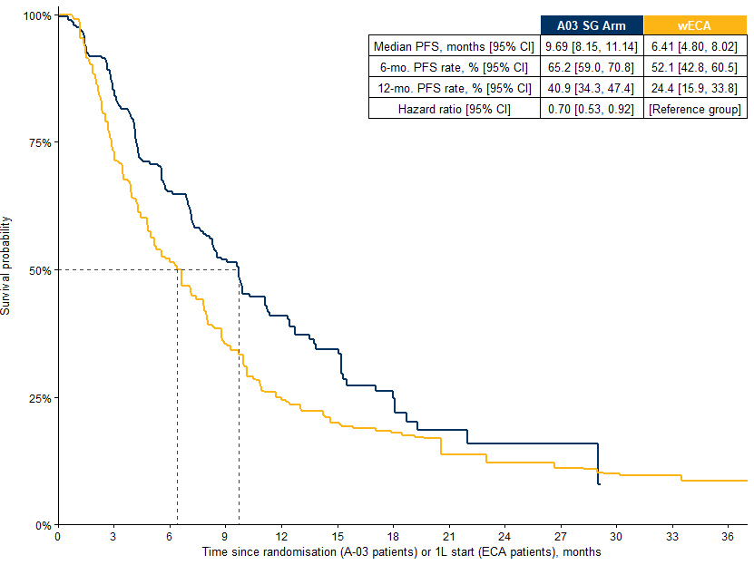

### ASCENT-03 SG Arm vs ASCENT-03 Control Arm vs Weighted ECA

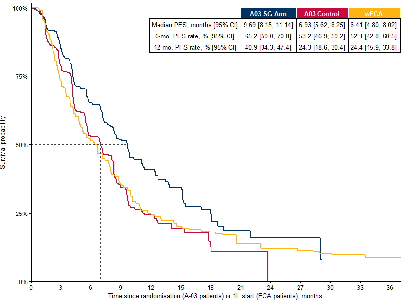

## Approach B

### ASCENT-03 SG Arm vs Weighted ECA

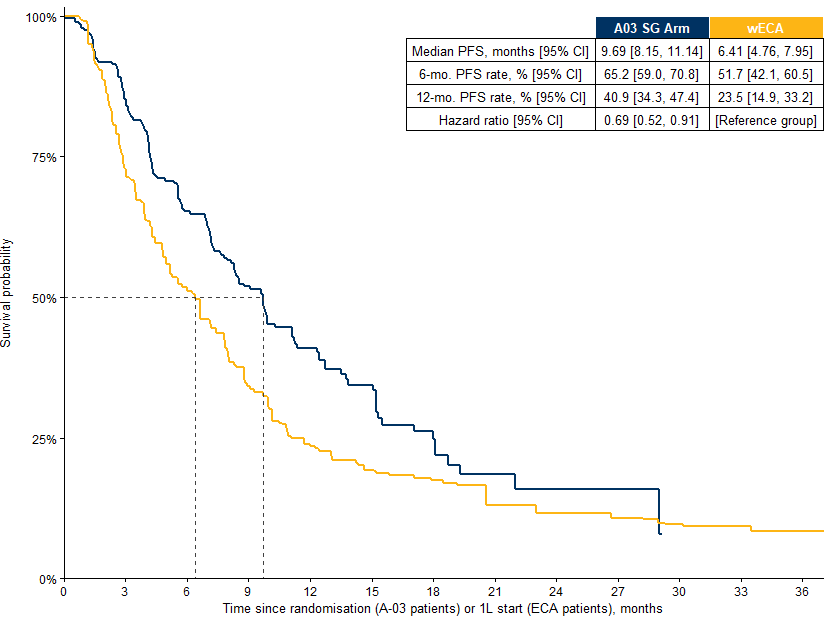

### ASCENT-03 SG Arm vs ASCENT-03 Control Arm vs Weighted ECA

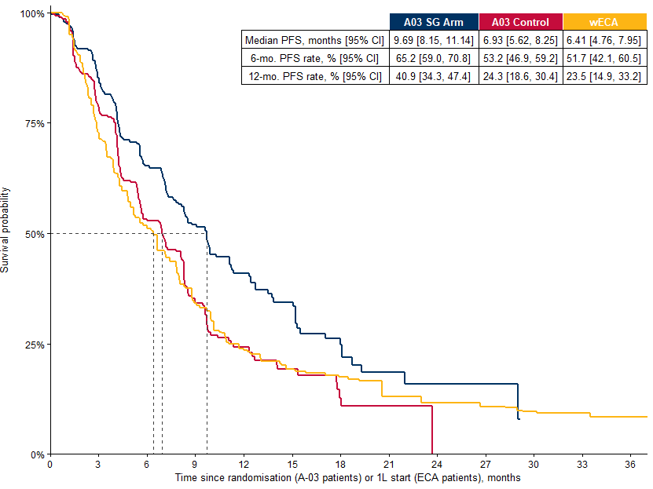

## Approach D

### ASCENT-03 SG Arm vs Weighted ECA

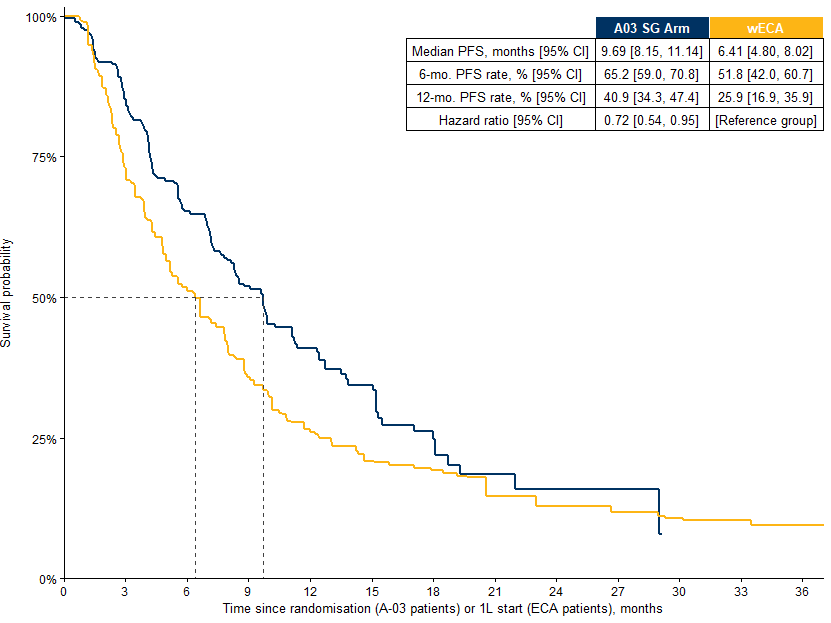

### ASCENT-03 SG Arm vs ASCENT-03 Control Arm vs Weighted ECA

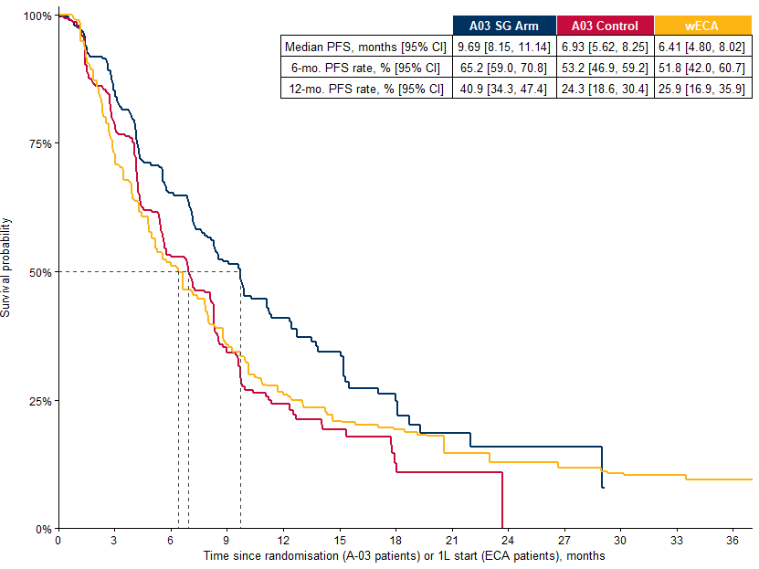